# PRACTICE TOPIC - MATPLOTLIB FUNCTIONS WITH VISUALIZATION

# Histogram chart

```python
In Matplotlib, we use the hist() function to create histograms
The hist() function will use an array of numbers to create a histogram, the array is sent into the function as an argument.
```

```python
x = np.random.normal(170, 10, 250)
print(x)
```

[output not shown]

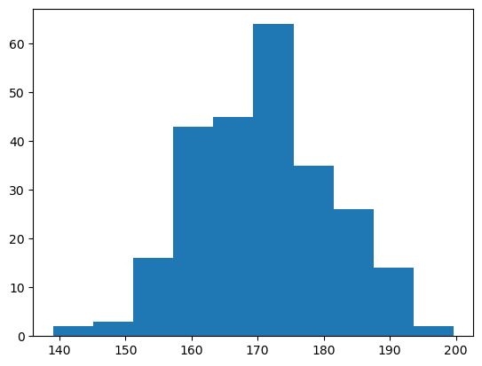

```python
x = np.random.normal(170, 10, 250)
plt.hist(x)
plt.show()
```

# Matplotlib Pie Charts

PIE======= Lables Start Angles Explode Shadow colors Legend With Header

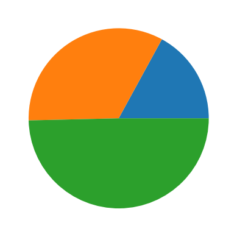

```python
p=[23,45,67]             #Simple PIE
plt.pie(p)
plt.show()
```

# Label

Add labels to the pie chart with the "Labels" parameter. The label parameter must be an array with one label for each wedge:

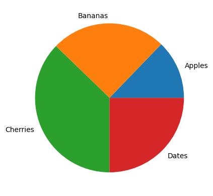

```python
p=[23,45,67,45]
mylabels = ["Apples", "Bananas", "Cherries", "Dates"]
plt.pie(p,labels=mylabels)
plt.show()
```

# Start Angle

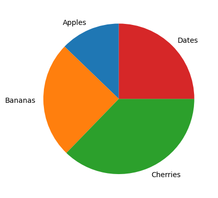

```python
p=[23,45,67,45]
mylabels = ["Apples", "Bananas", "Cherries", "Dates"]

plt.pie(p,labels=mylabels, startangle= 90)

plt.show()
```

# Explode

It shows each value represents how far from the center each wedge is displayed:it pulls the parameters

```python
#Example
#Pull the "Apples" wedge 0.2 from the center of the pie:
```

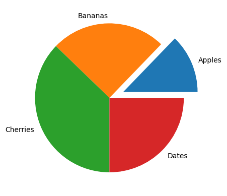

```python
p=[23,45,67,45]
mylabels = ["Apples", "Bananas", "Cherries", "Dates"]
myexplode=[0.2,0,0,0]

plt.pie(p,labels=mylabels, explode=myexplode)
plt.show()
```

# Shadow

Add a shadow to the pie chart by setting the shadows parameter to True:

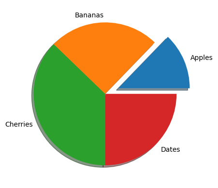

```python
p=[23,45,67,45]
mylabels = ["Apples", "Bananas", "Cherries", "Dates"]
myexplode=[0.2,0,0,0]

plt.pie(p,labels=mylabels, explode=myexplode, shadow= True)
plt.show()
```

# Colors

Example Specify a new color for each wedge:

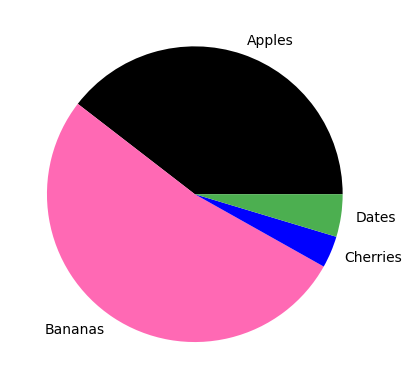

```python
y=[34,45,3,4]
mylabels = ["Apples", "Bananas", "Cherries", "Dates"]
mycolors = ["black", "hotpink", "b", "#4CAF50"]
plt.pie(y,labels=mylabels, colors=mycolors)
plt.show()
```

# Legend

To add a list of explanation for each wedge, use the legend() function:

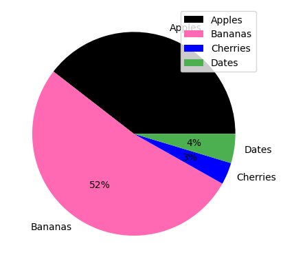

```python
y=[34,45,3,4]
mylabels = ["Apples", "Bananas", "Cherries", "Dates"]
mycolors = ["black", "hotpink", "b", "#4CAF50"]
plt.pie(y,labels=mylabels, colors=mycolors,autopct='%d%%')
plt.legend()
plt.show()
```

# Legend With Header

To add a header to the legend, add the "title" parameter to the legend function.

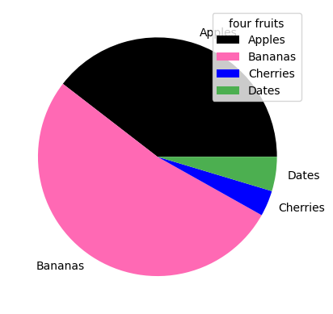

```python
y=[34,45,3,4]
mylabels = ["Apples", "Bananas", "Cherries", "Dates"]
mycolors = ["black", "hotpink", "b", "#4CAF50"]
plt.pie(y,labels=mylabels, colors=mycolors)
plt.legend(title='four fruits')
plt.show()
```

# Autopct= show percentage value inside of the plot